# R Open Labs, Week 7: ANOVA and the Linear Model

Chelsea Estancona

3/8/2018

```r
rm(list=ls())
library(foreign)
library(xtable)
library(stargazer)
```

Let’s dive in. We can use R’s built in data, mtcars, to illustrate our two statistical tests.

First off - ANOVA, or `analysis of variance.’ We’re using ANOVA in this case to analyze the relationship between the number of cylinders a car’s engine has and its miles per gallon.

```r
data(mtcars)

#Setting up our variables
mtcars$cyl_cat<-as.factor(mtcars$cyl)

#one-way ANOVA
aov_1<-with(mtcars, aov(mpg~cyl_cat))

summary(aov_1)   #show the summary table
```

```
##             Df Sum Sq Mean Sq F value   Pr(>F)
## cyl_cat      2  824.8   412.4    39.7 4.98e-09 ***
## Residuals   29  301.3    10.4
## ---
## Signif. codes:  0 '***' 0.001 '**' 0.01 '*' 0.05 '.' 0.1 ' ' 1
```

```r
print(model.tables(aov_1,"means"),digits=3)  #report the means and the number of subjects/cell
```

```
## Tables of means
## Grand mean
##
## 20.09062
##
##  cyl_cat
##        4    6    8
##     26.7 19.7 15.1
## rep 11.0  7.0 14.0
```

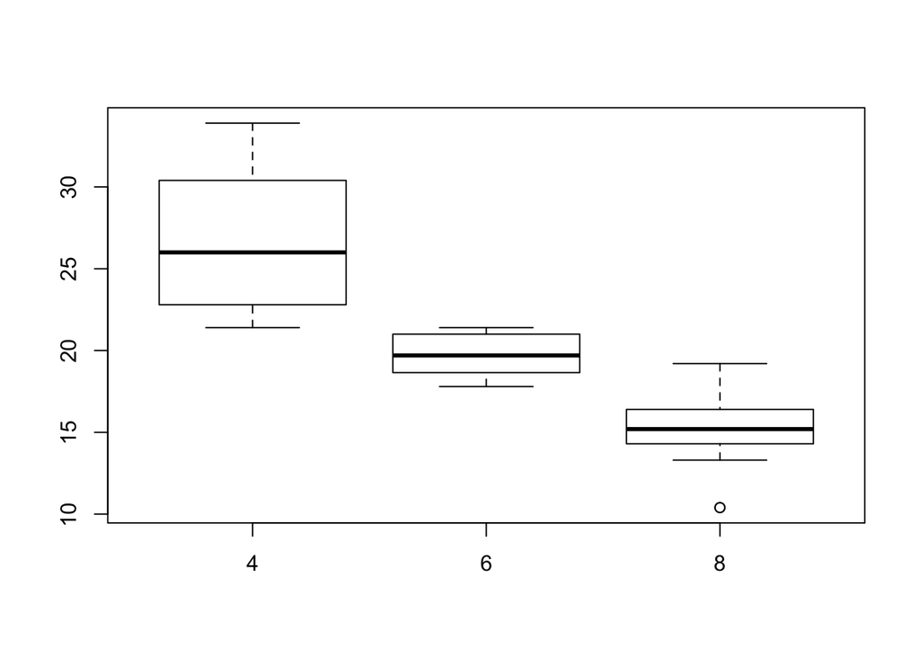

```r
boxplot(mpg~cyl_cat, data=mtcars) # produce a simple boxplot of miles per gallon, by cylinder
```

It’s trivial to add additional factors - we we can look at a design with the number of engine cylinders and the # of barrels in a car’s carburetor.

```r
#Setting up another variable
mtcars$carb_cat<-as.factor(mtcars$carb)

#two-way (between) ANOVA
aov_2<-with(mtcars, aov(mpg~cyl_cat*carb_cat))

summary(aov_2)
```

```
##                  Df Sum Sq Mean Sq F value   Pr(>F)
## cyl_cat           2  824.8   412.4  38.000 5.13e-08 ***
## carb_cat          5   30.6     6.1   0.564    0.726
## cyl_cat:carb_cat  1   21.0    21.0   1.939    0.177
## Residuals        23  249.6    10.9
## ---
## Signif. codes:  0 '***' 0.001 '**' 0.01 '*' 0.05 '.' 0.1 ' ' 1
```

```r
m2<-lm(mpg~disp+wt, data=mtcars) #can specify data within the lm function
summary(m2)
```

```
##
## Call:
## lm(formula = mpg ~ disp + wt, data = mtcars)
##
## Residuals:
##     Min      1Q  Median      3Q     Max
## -3.4087 -2.3243 -0.7683  1.7721  6.3484
##
## Coefficients:
##             Estimate Std. Error t value Pr(>|t|)
## (Intercept) 34.96055    2.16454  16.151 4.91e-16 ***
## disp        -0.01773    0.00919  -1.929  0.06362 .
## wt          -3.35082    1.16413  -2.878  0.00743 **
## ---
## Signif. codes:  0 '***' 0.001 '**' 0.01 '*' 0.05 '.' 0.1 ' ' 1
##
## Residual standard error: 2.917 on 29 degrees of freedom
## Multiple R-squared:  0.7809, Adjusted R-squared:  0.7658
## F-statistic: 51.69 on 2 and 29 DF,  p-value: 2.744e-10
```

It should be evident that the ‘summary’ function provides lots of valuable information about the model we’ve created. We can also extract different information if we need, for example, just the coefficients, or just the residuals:

```r
m2$coefficients #extract coefficients
m2$residuals #extract residuals
m2$fitted.values #extract y hat
model.matrix(m2) #extract design matrix
```

What if we wanted to include an interaction term?

```r
m3<-lm(mpg~disp+wt+disp*wt, data=mtcars) #use * for interaction- include both variables
summary(m3)
```

```
##
## Call:
## lm(formula = mpg ~ disp + wt + disp * wt, data = mtcars)
##
## Residuals:
##    Min     1Q Median     3Q    Max
## -3.267 -1.677 -0.836  1.351  5.017
##
## Coefficients:
##              Estimate Std. Error t value Pr(>|t|)
## (Intercept) 44.081998   3.123063  14.115 2.96e-14 ***
## disp        -0.056358   0.013239  -4.257  0.00021 ***
## wt          -6.495680   1.313383  -4.946 3.22e-05 ***
## disp:wt      0.011705   0.003255   3.596  0.00123 **
## ---
## Signif. codes:  0 '***' 0.001 '**' 0.01 '*' 0.05 '.' 0.1 ' ' 1
##
## Residual standard error: 2.455 on 28 degrees of freedom
## Multiple R-squared:  0.8501, Adjusted R-squared:  0.8341
## F-statistic: 52.95 on 3 and 28 DF,  p-value: 1.158e-11
```

How might we present these results in a table that we can put into LaTeX?

```r
stargazer(m3)
xtable(m3)
```

Or, to export results as a .txt file to use in Word?

```r
write.table(as.data.frame(rbind(m3$coefficients)), file = "ols_m3.txt", sep = ",", quote = FALSE, row.names = F)
```

What if we wanted to use our linear model to make predictions from a new set of observations? The function predict() gives us an easy method to do so.

```r
set.seed(22135)

wt_2<-runif(12, 1, 4)
disp_2<-runif(12, 100, 400)

new_data<-data.frame(wt_2, disp_2)
colnames(new_data)<-c("wt", "disp") #column names must be the same as the original data used for the model!

mpg_predictions<-predict(m3, new_data)

cbind(new_data, mpg_predictions)
```

```
##          wt     disp mpg_predictions
## 1  2.973760 132.4275        21.91172
## 2  1.863880 220.4740        24.35951
## 3  3.945431 146.5211        16.96285
## 4  2.599597 344.4467        18.26476
## 5  1.256100 276.4541        24.40708
## 6  2.382892 126.9106        24.99093
## 7  1.594144 191.0662        26.52413
## 8  2.732374 230.4842        20.71541
## 9  2.900342 356.0676        17.26338
## 10 2.442960 284.5188        20.31442
## 11 2.774360 164.1806        22.13950
## 12 2.755081 291.0513        19.16898
```

Additional resources:

https://www.r-bloggers.com/r-tutorial-series-simple-linear-regression/

Full example: http://rstudio-pubs-static.s3.amazonaws.com/63893_9f6bc9cd73ad47aab3aa85d0193244d9.html

### Exercise: Produce R code and output for the following:

#### Part 1:

-Access the R dataset PlantGrowth (or use your own)!

-Produce a boxplot of plants’ growth, by category of treatment - you may need to adjust the factor variable to make a sensible plot. (For an extra challenge, produce this plot using ggplot2)

-Run ANOVA (weight ~ group).

#### Part 2:

-Access the R dataset freeny (data on quarterly revenues)

-Fit a linear model on the first 20 observations, with at least two independent variables and an interaction term.

-Summarize your linear model. Include the code to create a table from it.

-Generate predicted y values for the remaining 19 observations.

[Let us know what you think of this lesson!](https://unc.az1.qualtrics.com/jfe/form/SV_8e1zRY2rlFUYBMx)